# Workflows for predicting staple food systems with association rule mining

M.G. Walsh, R. Manners, J. Meliyo, J. Rutebuka and M. Broadley

04, October, 2021

# Introduction

Staple foods make up the dominant food energy intake in a population’s diet. While there are >50,000 edible plants in the world, just 15 of these provide ~90% of the world’s [gross food energy (GE)](https://www.sciencedirect.com/topics/agricultural-and-biological-sciences/food-energy). Rice, maize, and wheat alone make up ~60% of the world’s GE. Other, more regional/local staples include: millet and sorghum, pulses such as beans, lentils and chickpeas, roots and tubers such as potatoes, cassava, yams, and taro, and animal foods such as meat, fish, and dairy products (see [FAO](http://www.fao.org/3/AC832E/ac832e06.htm)). In turn the specific combinations of staple foods that are consumed by people are thought to have specific population-level nutritional, health as well as environmental outcomes that are not well supported by local evidence. The old adage [“You are what you eat”](https://www.phrases.org.uk/meanings/you-are-what-you-eat.html) also implies a level of personal circumstances and choices in this regard.

[Association rule learning (ARL)](https://en.wikipedia.org/wiki/Association_rule_learning) is used to answer common exploratory questions like: If someone walks into a supermarket and buys charcoal, what is the probability that this person will also buy steak (or chicken and Bar-B-Que sauce, etc)? This is also why it is often referred to as [market basket analysis](https://www.sciencedirect.com/topics/computer-science/market-basket-analysis).

The majority of East African food production systems are analogous to a supermarket situation in that fields are [intercropped](https://en.wikipedia.org/wiki/Intercropping) with several staple food crops, rather than [monocropped](https://en.wikipedia.org/wiki/Monocropping). Even quite small, 0.25 ha, cropland areas will commonly be planted with multiple staple food crops during any given season. However, which specific crops are grown together in a given small area or environment, and how these combinations may be evolving due to external factors remain uncertain and largely unquantified. We’ll use ARL in this notebook to explore staple food systems based on the occurrence of crop indicator species that can subsequently be used for practical mapping and monitoring applications. There is also the [*“Bear Grylls”*](https://www.beargrylls.com/) analogy that poses a similar question in that if you observe chickens and banana what is the probability that you are close to buildings in a remote area of East Africa? It turns out that the odds of that are pretty good, though the the likelihood of encountering such a situation is not!

*The main objective of this notebook is to introduce starter code for exploration, discovery and identification of staple food systems in Tanzania and Rwanda. The data include georeferenced observations of the occurrence of: cattle, sheep, goats, poultry, maize, wheat, sorghum, rice, bean, cowpea, pigeon pea, soybean, groundnut, Irish potato, sweet potato, cassava, yam, banana, sugarcane, and sunflower. The markdown notebook presented here is maintained on [Github](https://github.com/mgwalsh/RwaSIS/blob/master/Cropping%20_sytems.Rmd), and you can fork and alter it from there for your reference, and as you see fit.*

# General data setup

The example data we will be using were generated by the [TanSIS](https://doi.org/10.17605/OSF.IO/4NGAU) and [RwaSIS](https://doi.org/10.17605/OSF.IO/Y9ZUT) projects in Tanzania and Rwanda. They currently consist of >16k georeferenced, time stamped, and photo tagged, field survey observations of staple crops that were observed in 0.25 ha circular primary sampling units (PSU, ~28.2 m radius), in proportion to their national occurrence, between 2015-2021. The spatially representative cropland sampling frames that are used in both currently ongoing national survey data collections are described in [Walsh, Rutebuka and Manners (2021)](https://github.com/mgwalsh/RwaSIS/blob/master/RwaSIS_cropland_sample.Rmd). A field data collection framework (CropScout) has also been posted on [KoboToolbox](https://kobo.humanitarianresponse.info/#/forms/a3jwzkBTtDvdaZJgR6YjAe/), which you can either use directly or modify for your own use with Open Data Kit ([ODK](https://opendatakit.org/)).

To actually run this notebook, you will need to load the R-packages that are indicated in the chunk directly below to download, assemble and model the data. You can find all of the documentation of these packages on [CRAN](https://cran.r-project.org/).

```r
# Package names
packages <- c("osfr", "tidyverse", "leaflet", "arules", "arulesViz", "caret", "arulesCBA")

# Install packages
installed_packages <- packages %in% rownames(installed.packages())
if (any(installed_packages == FALSE)) {
  install.packages(packages[!installed_packages])
}

# Load packages
invisible(lapply(packages, library, character.only = TRUE))
```

The survey (label) data downloads can be obtained with this next chunk. It also generates an overview map of where the PSUs were collected in Tanzania and Rwanda (not shown, but in the markdown document) … you can click and zoom into the individual locations that we have surveyed thus far.

```r
# Create a data folder in  your current working directory
dir.create("Food_system", showWarnings=F)
setwd("./Food_system")
dir.create("Results", showWarnings=F)

# Download crop survey data: https://osf.io/2unc3/
osf_retrieve_file("2unc3") %>% osf_download(conflicts = "overwrite")
staple <- read.table("TZ_RW_staples.csv", header = T, sep = ",")
staple$sdiv <- rowSums(staple[, 6:25]) ## count of number of staples at each survey location
```

[interactive chart not shown]

To prepare the data that are used here for the association rule mining workflow we will need to do a bit wrangling initially to select and recode the variables of interest. The [`arules`](https://www.rdocumentation.org/packages/arules/versions/1.6-8) package, which we will be using further below, only processes factor and logical variables. Note that this chunk is a bit ugly, but it works, and we could always convert it into a proper function as more data with different staple crops or from different places become available.

```r
# Initially select the variables (columns) of interest
staple_ar <- staple[ , c(3:4,1,5:25,27)]

# This does the recoding bits
staple_ar$survey <- as.factor(staple_ar$survey)
staple_ar$build <- as.factor(ifelse(staple_ar$build == 1, "yes", "no"))
staple_ar$catt <- as.logical(staple_ar$catt)
staple_ar$shee <- as.logical(staple_ar$shee)
staple_ar$goat <- as.logical(staple_ar$goat)
staple_ar$poul <- as.logical(staple_ar$poul)
staple_ar$maiz <- as.logical(staple_ar$maiz)
staple_ar$whea <- as.logical(staple_ar$whea)
staple_ar$sorg <- as.logical(staple_ar$sorg)
staple_ar$rice <- as.logical(staple_ar$rice)
staple_ar$bean <- as.logical(staple_ar$bean)
staple_ar$cpea <- as.logical(staple_ar$cpea)
staple_ar$pige <- as.logical(staple_ar$pige)
staple_ar$soyb <- as.logical(staple_ar$soyb)
staple_ar$gnut <- as.logical(staple_ar$gnut)
staple_ar$pota <- as.logical(staple_ar$pota)
staple_ar$spot <- as.logical(staple_ar$spot)
staple_ar$cass <- as.logical(staple_ar$cass)
staple_ar$yam  <- as.logical(staple_ar$yam)
staple_ar$bana <- as.logical(staple_ar$bana)
staple_ar$cane <- as.logical(staple_ar$cane)
staple_ar$sunf <- as.logical(staple_ar$sunf)

# Generates a glimpse of the resulting dataframe
glimpse(staple_ar)
```

```
## Rows: 16,490
## Columns: 25
## $ lon    <dbl> 36.55824, 36.55903, 36.55129, 36.54916, 36.55100, 36.55270, 36.…
## $ lat    <dbl> -3.441613, -3.442471, -3.408656, -3.440615, -3.441583, -3.44160…
## $ survey <fct> TZ, TZ, TZ, TZ, TZ, TZ, TZ, TZ, TZ, TZ, TZ, TZ, TZ, TZ, TZ, TZ,…
## $ build  <fct> no, no, yes, yes, no, no, no, no, yes, yes, yes, no, no, no, no…
## $ catt   <lgl> FALSE, FALSE, FALSE, FALSE, FALSE, FALSE, FALSE, FALSE, FALSE, …
## $ shee   <lgl> FALSE, FALSE, FALSE, FALSE, FALSE, FALSE, FALSE, FALSE, FALSE, …
## $ goat   <lgl> FALSE, FALSE, FALSE, FALSE, FALSE, FALSE, FALSE, FALSE, FALSE, …
## $ poul   <lgl> FALSE, FALSE, FALSE, FALSE, FALSE, FALSE, FALSE, FALSE, FALSE, …
## $ maiz   <lgl> TRUE, TRUE, TRUE, TRUE, TRUE, TRUE, TRUE, TRUE, FALSE, FALSE, F…
## $ whea   <lgl> FALSE, FALSE, FALSE, FALSE, FALSE, FALSE, FALSE, FALSE, FALSE, …
## $ sorg   <lgl> FALSE, FALSE, FALSE, FALSE, FALSE, FALSE, FALSE, FALSE, FALSE, …
## $ rice   <lgl> FALSE, FALSE, FALSE, FALSE, FALSE, FALSE, FALSE, FALSE, FALSE, …
## $ bean   <lgl> TRUE, TRUE, TRUE, TRUE, TRUE, TRUE, TRUE, TRUE, FALSE, FALSE, F…
## $ cpea   <lgl> FALSE, FALSE, FALSE, FALSE, FALSE, FALSE, FALSE, FALSE, FALSE, …
## $ pige   <lgl> FALSE, FALSE, TRUE, FALSE, FALSE, FALSE, FALSE, FALSE, FALSE, F…
## $ soyb   <lgl> FALSE, FALSE, FALSE, FALSE, FALSE, FALSE, FALSE, FALSE, FALSE, …
## $ gnut   <lgl> FALSE, FALSE, FALSE, FALSE, FALSE, FALSE, FALSE, FALSE, FALSE, …
## $ pota   <lgl> FALSE, FALSE, FALSE, FALSE, FALSE, FALSE, FALSE, FALSE, FALSE, …
## $ spot   <lgl> FALSE, FALSE, FALSE, FALSE, FALSE, FALSE, FALSE, FALSE, FALSE, …
## $ cass   <lgl> FALSE, FALSE, FALSE, FALSE, FALSE, FALSE, FALSE, FALSE, FALSE, …
## $ yam    <lgl> FALSE, FALSE, FALSE, FALSE, FALSE, FALSE, FALSE, FALSE, FALSE, …
## $ bana   <lgl> FALSE, FALSE, FALSE, FALSE, FALSE, FALSE, FALSE, FALSE, FALSE, …
## $ cane   <lgl> FALSE, FALSE, FALSE, FALSE, FALSE, FALSE, FALSE, FALSE, FALSE, …
## $ sunf   <lgl> FALSE, FALSE, FALSE, FALSE, FALSE, FALSE, FALSE, FALSE, FALSE, …
## $ sdiv   <dbl> 2, 2, 3, 2, 2, 2, 2, 2, 0, 3, 0, 1, 2, 0, 2, 2, 0, 2, 2, 0, 3, …
```

```r
# Write out tidy dataframe
write.csv(staple_ar, "./Food_system/Results/TZ_RW_staple_food.csv")
```

# Exploratory data analyses

This section provides some initial EDAs for these data. One could also do this with R-base and/or `dplyr`, but the [`arules`](https://www.rdocumentation.org/packages/arules/versions/1.6-8) package provides some useful wrapper functions for this, which run quickly.

```r
# Select initial crop occurrence variables and convert these to "transactions"
crops <- staple_ar[ , c(5:24)]
trans <- as(crops, "transactions")
```

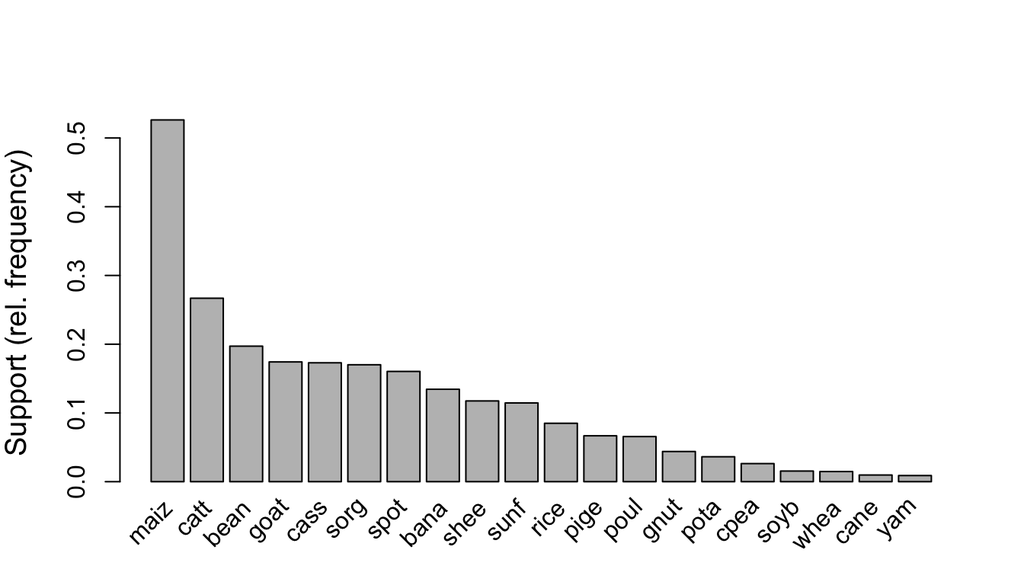

Overall support for individual staple food crop occurrences in Tanzania and Rwanda.

```r
itemFrequencyPlot(trans, topN = 20, ylab = "Support (rel. frequency)", cex.lab = 1.2)
```

The graph provides an indication of the overall level of support for the individual staple crops that are presented here. Maize is the most frequent, yam is the most infrequent. This means that various staple combinations with maize are likely to have more overall support than any crop combinations with yam. You can also subset the data for comparison, e.g. by survey, with something like the following:

```r
# Rwanda subset
crops_RW <- staple_ar[which(staple_ar$survey == 'RW'), ]
crops_RW <- crops_RW[ , c(5:24)]
trans_RW <- as(crops_RW, "transactions")

# Tanzania subset
crops_TZ <- staple_ar[which(staple_ar$survey == 'TZ'), ]
crops_TZ <- crops_TZ[ , c(5:24)]
trans_TZ <- as(crops_TZ, "transactions")
```

You can then plot the staple crop-level support comparison for the 2 surveys with:

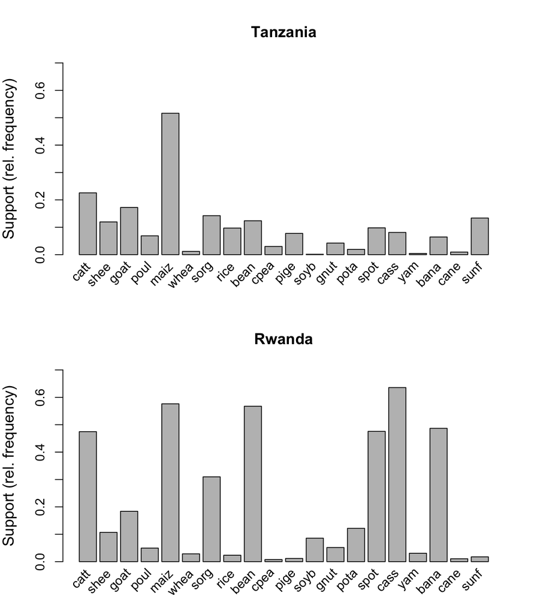

Differences in support for staple food crop occurrences in Tanzania and Rwanda.

```r
par(mfrow = c(2,1))
itemFrequencyPlot(trans_TZ, ylab = "Support (rel. frequency)", main = "Tanzania",
                  ylim = c(0,0.7), cex.lab = 1.2)
itemFrequencyPlot(trans_RW, ylab = "Support (rel. frequency)", main = "Rwanda",
                  ylim = c(0, 0.7), cex.lab = 1.2)
```

Based on this, you can to tell that the main staple distributions grown in Tanzania are quite different from those in Rwanda. Also not surprisingly, the [beta-diversity](https://en.wikipedia.org/wiki/Beta_diversity) of staple crop combinations indexed by `sdiv` between the two national survey samples is also quite different, as is shown in the next plot.

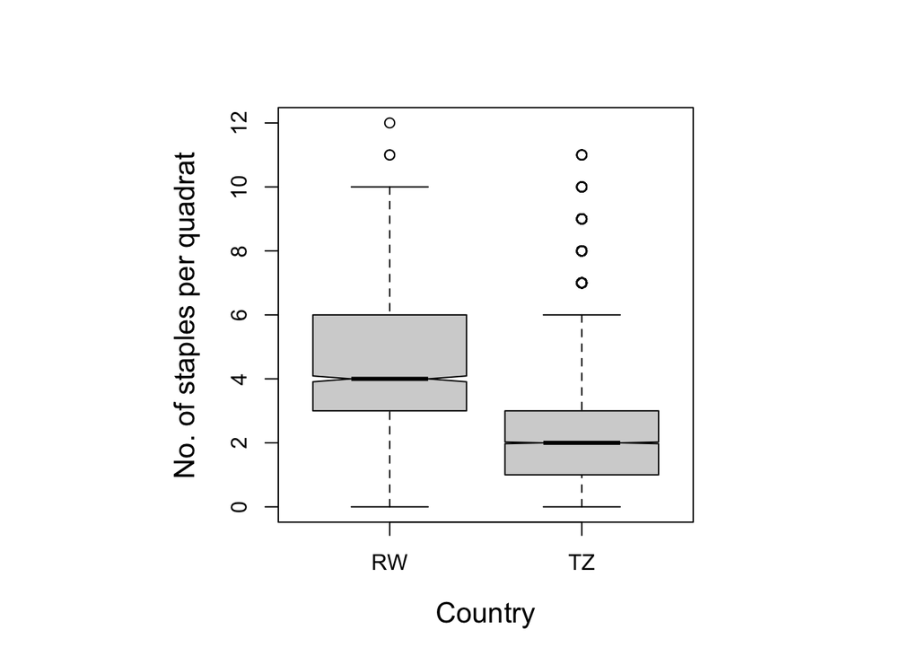

Conditional staple food crop diversity by survey.

```r
par(pty = "s")
boxplot(sdiv~survey, notch = T, ylab = "No. of staples per quadrat", xlab = "Country",
        cex.lab = 1.3, staple_ar)
```

This will influence the different intercropped combinations that are likely to occur in the two countries, and those differences would need to be considered in any subsequent mapping and/or staple food distribution monitoring applications. There are good reasons for differences that appear to be primarily associated with the differences of cropland occurrences in proximity to buildings between the two countries.

In general, there are large also diversity differences between staple crops that are grown in proximity to buildings versus those that are grown in more distant/outlying fields, as is shown in the next figure.

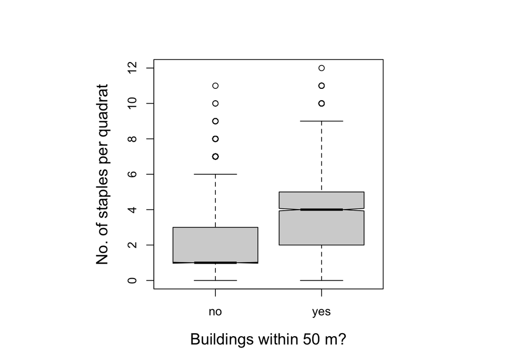

Conditional staple food crop diversity by proximity to buildings indicator.

```r
par(pty = "s")
boxplot(sdiv~build, notch = T, ylab = "No. of staples per quadrat", xlab = "Buildings within 50 m?",
        cex.lab = 1.3, staple_ar)
```

In this case the differences between the two surveys may simply represent a confounding variable that can be accounted for by considering the potentially more causal proximity to buildings in each country. People do tend to plant more diverse staples in proximity to their homes. We will look at this in more detail further below.